# Session 4 Homework Solutions

## Part A - Classes and Inheritence

Using the `Animal` base class below as a starting point...

1. Create as `Speech` mixin that allows the animal to:
   - Select one of the learned sounds to use when .speak() is called (without modifying .speak() in Animal).
   - Add a .repeat() method that takes a string input and returns it in the form: "{animal_name} says: {input_string}"
2. Using the `Animal` base class and the `Speech` mixin, create a `Parrot` class.

**Bonus**: Add `__str__()` and `__repr__()` methods to your Parrot class so that:

- Print(parrot) shows the parrot’s name and current sound.
- Calling the object in the console shows its name and the list of learned sounds.

> Hint: It may be helpful to have a sound list!

```
## Animal base class
class Animal:  ## class definition
    def __init__(self, name, breed, sound):
        self.name = name
        self.breed = breed
        self.sound = sound

    def speak(self):
        return f"{self.name} says {self.sound}!"
```

```
## Create `Speech` mixin
class Speech:  ## mixin that adds behaviors to animal class
    def __init__(self, *args, **kwargs):
        super().__init__(*args, **kwargs)
        self.sound_list = [self.sound]  ## create an empty sound list.

    def learn_sound(self, sound):  ## use this as a base to create your 'learn' method
        if sound not in self.sound_list:
            self.sound_list.append(sound)
            return f"{self.name} learned a new sound: {sound}!"
        return f"{self.name} already knows {sound}!"

    def set_sound(self, sound_number):
        if 0 <= sound_number < len(self.sound_list):
            self.sound = self.sound_list[sound_number]
            return f"Set sound to: {self.sound}!"
        else:
            return (
                f"Invalid input. Must be a number between 0 and {len(self.sound_list)}."
            )
```

```
## Create Parrot Class:
class Parrot(Animal, Speech):  ## inherit from Speech and Animal
    def __init__(
        self, name, breed="parrot", sound="squawk"
    ):  ## add arguments here as needed
        super().__init__(name, breed, sound)  ## initialize Animal
        Speech.__init__(self)  ## initialize Speech

    def __str__(self):
        return f"Name: {self.name}. Current sound: {self.sound}"

    def __repr__(self):
        return f"Name: {self.name}. Current sound: {self.sound} \n Known sounds: {self.sound_list}"
```

3. Create an instance of `Parrot`  
   a: Teach it the following:  
   - "Hello!"  
   - "{name} wants a cracker!  
   b: Change the sound used in `.speak()` to either of the learned sounds.  
   c: Have the parrot repeat a string of your choice.

```
polly = Parrot("Polly")
print(polly.speak())

polly.learn_sound("Hello!")
polly.learn_sound("Polly wants a cracker!")

polly.set_sound(2)

print(polly.speak())

print(polly)

polly
```

```
Polly says squawk!
Polly says Polly wants a cracker!!
Name: Polly. Current sound: Polly wants a cracker!
```

```
Name: Polly. Current sound: Polly wants a cracker!
 Known sounds: ['squawk', 'Hello!', 'Polly wants a cracker!']
```

## Part B - Using Machine Learning Modules

1. Using the sklearn documentation as a reference (https://scikit-learn.org/stable/user_guide.html), pick a model not shown in the demo and use it to either cluster or classify the irises from the iris dataset.
   - Scale the data using StandardScalar
   - If classifying split into train/test data
2. Create a figure showing the results of the clustering/classification. *The scikit-learn documentation may be helpful here!*

> Note: The answer key is made for decision tree (classification) and hierarchical (agglomerative) clustering!

### Data Setup

```
import pandas as pd
from sklearn.datasets import load_iris

## load the iris dataset
iris = load_iris()
X, y = (
    iris.data,
    iris.target,
)  ## iris.data = the predictors (in array form), iris.target = the iris species

## Check what the data looks like
print("Predictors: ", X[0:5,], "\nTargets", y[0:5])

## note: for the iris dataset, the feature names are stored in iris.feature_names

## if you want a pandas dataset:
iris_df = pd.DataFrame(data=iris.data, columns=iris.feature_names)

# Add the target as a new column
iris_df["species"] = pd.Categorical.from_codes(iris.target, iris.target_names)

# Create a summary table grouped by species
summary_table = iris_df.groupby("species").agg(
    {
        "sepal length (cm)": ["mean", "std", "min", "max"],
        "sepal width (cm)": ["mean", "std", "min", "max"],
        "petal length (cm)": ["mean", "std", "min", "max"],
        "petal width (cm)": ["mean", "std", "min", "max"],
    }
)

# Display the summary table
display(summary_table)
```

```
Predictors:  [[5.1 3.5 1.4 0.2]
 [4.9 3.  1.4 0.2]
 [4.7 3.2 1.3 0.2]
 [4.6 3.1 1.5 0.2]
 [5.  3.6 1.4 0.2]]
Targets [0 0 0 0 0]
```

| species | sepal length (cm) mean | sepal length (cm) std | sepal length (cm) min | sepal length (cm) max | sepal width (cm) mean | sepal width (cm) std | sepal width (cm) min | sepal width (cm) max | petal length (cm) mean | petal length (cm) std | petal length (cm) min | petal length (cm) max | petal width (cm) mean | petal width (cm) std | petal width (cm) min | petal width (cm) max |
| --- | --- | --- | --- | --- | --- | --- | --- | --- | --- | --- | --- | --- | --- | --- | --- | --- |
| setosa | 5.006 | 0.352490 | 4.3 | 5.8 | 3.428 | 0.379064 | 2.3 | 4.4 | 1.462 | 0.173664 | 1.0 | 1.9 | 0.246 | 0.105386 | 0.1 | 0.6 |
| versicolor | 5.936 | 0.516171 | 4.9 | 7.0 | 2.770 | 0.313798 | 2.0 | 3.4 | 4.260 | 0.469911 | 3.0 | 5.1 | 1.326 | 0.197753 | 1.0 | 1.8 |
| virginica | 6.588 | 0.635880 | 4.9 | 7.9 | 2.974 | 0.322497 | 2.2 | 3.8 | 5.552 | 0.551895 | 4.5 | 6.9 | 2.026 | 0.274650 | 1.4 | 2.5 |

## Solution: Clustering - Agglomerative (hierarchical) Clustering

```
import pandas as pd
import numpy as np

from plotnine import *
import seaborn as sns
import matplotlib.pyplot as plt

from great_tables import GT

## sklearn imports

## import classes
from sklearn.preprocessing import StandardScaler
from sklearn.cluster import AgglomerativeClustering
from scipy.cluster.hierarchy import linkage, dendrogram

## import functions
from sklearn.model_selection import train_test_split
from sklearn.metrics import accuracy_score, classification_report, adjusted_rand_score
```

```
# Step 1: Scale the data
scaler = StandardScaler()
X_scaled = scaler.fit_transform(X)

# Step 2: Fit the model with 3 clusters
clustering = AgglomerativeClustering(n_clusters=3)
iris_df["clusters"] = clustering.fit_predict(X_scaled)

# Step 2.5 - optional: Compute linkage matrix for dendrogram (this is separate from AgglomerativeClustering)
Z = linkage(X_scaled, method="ward")

plt.figure(figsize=(10, 6))
plt.title("Hierarchical Clustering Dendrogram")
dendrogram(Z, truncate_mode="level", p=2)
plt.xlabel("Sample Index or Cluster Size")
plt.ylabel("Distance")
plt.show()
```

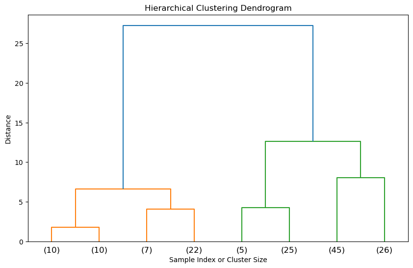

```
# Step 3: Count occurrences of species-cluster combinations
heatmap_data = iris_df.groupby(["species", "clusters"]).size().unstack(fill_value=0)

# Step 4: Make Heatmap
fig, ax = plt.subplots(figsize=(7, 5))

sns.heatmap(heatmap_data, annot=True, fmt="d", cmap="Blues", cbar=False, ax=ax)

ari = adjusted_rand_score(iris_df["species"], iris_df["clusters"])

ax.set_title(f"Species vs Cluster Assignment \nAdjusted Rand Index (ARI): {ari:.2f}")
ax.set_xlabel("Cluster")
ax.set_ylabel("Species")

plt.tight_layout()
plt.show()
```

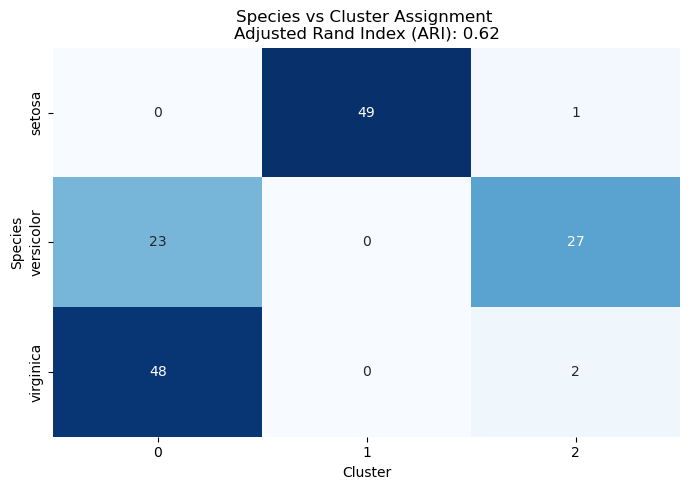

## Solution: Classification - Decision Tree Classifier

```
import pandas as pd
import numpy as np

from plotnine import *
import seaborn as sns
import matplotlib.pyplot as plt

from great_tables import GT

## sklearn imports

## import classes
from sklearn.preprocessing import StandardScaler
from sklearn.tree import DecisionTreeClassifier, plot_tree

## import functions
from sklearn.model_selection import train_test_split
from sklearn.metrics import classification_report
```

```
## step 1: scale the data
scaler = StandardScaler()
X_scaled = scaler.fit_transform(X)

## step 2: train-test split
X_train, X_test, y_train, y_test = train_test_split(
    X_scaled, y, test_size=0.3, random_state=42
)

## step 3: make an instance of the decision tree and fit it
tree = DecisionTreeClassifier()
tree.fit(X_train, y_train)

## step 3.5 plot the decision tree
fig, ax = plt.subplots(figsize=(20, 15))

plot_tree(
    tree,
    filled=True,
    feature_names=iris.feature_names,
    class_names=iris.target_names,
    ax=ax,
)

ax.set_title("Decision Tree: Iris Dataset")

plt.show()
```

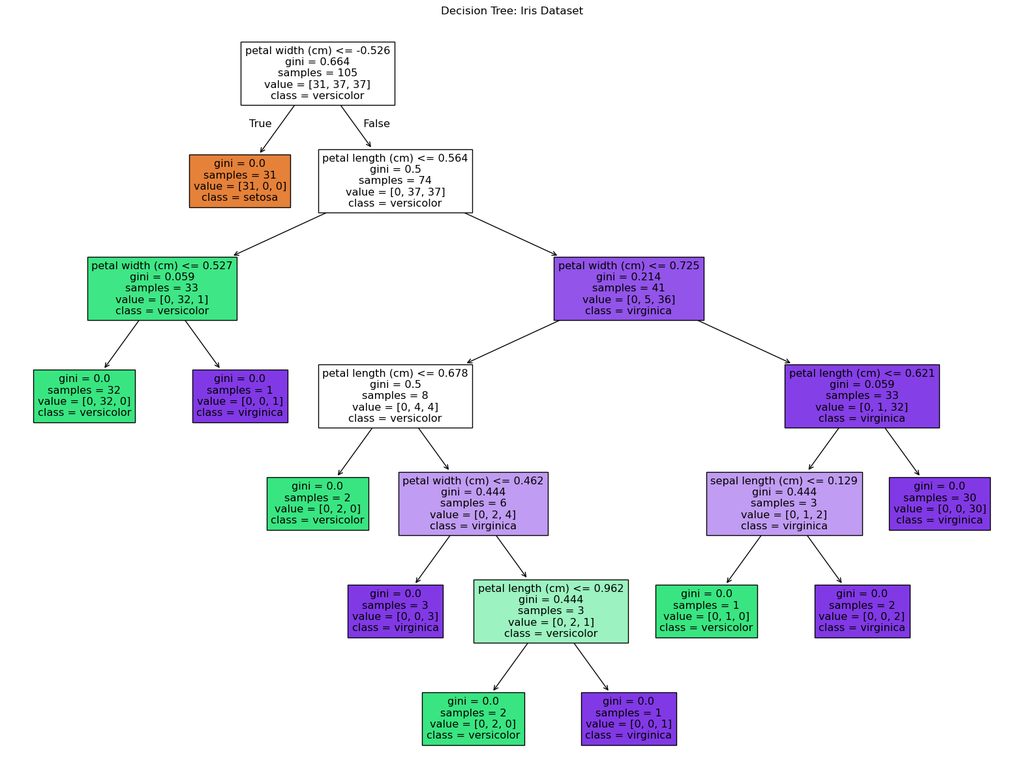

```
## step 4: predict class of samples
y_pred = tree.predict(X_test)

## step 5: print classification report
print("Classification Report: \n", classification_report(y_test, y_pred))
```

```
Classification Report:
               precision    recall  f1-score   support

           0       1.00      1.00      1.00        19
           1       1.00      1.00      1.00        13
           2       1.00      1.00      1.00        13

    accuracy                           1.00        45
   macro avg       1.00      1.00      1.00        45
weighted avg       1.00      1.00      1.00        45
```